# Analysis of Dental Magic’s Human Resources Dataset

Jennie Eardley

08/10/2020

**Data Source**

This is a dataset based around a fictional company called Dental Magic, created to teach HR analytics. The dataset is from Kaggle and is available here: https://www.kaggle.com/rhuebner/human-resources-data-set

**Recruitment**

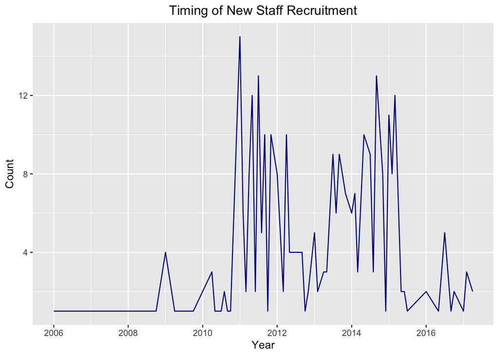

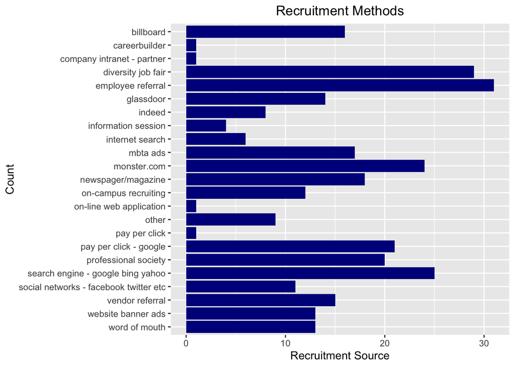

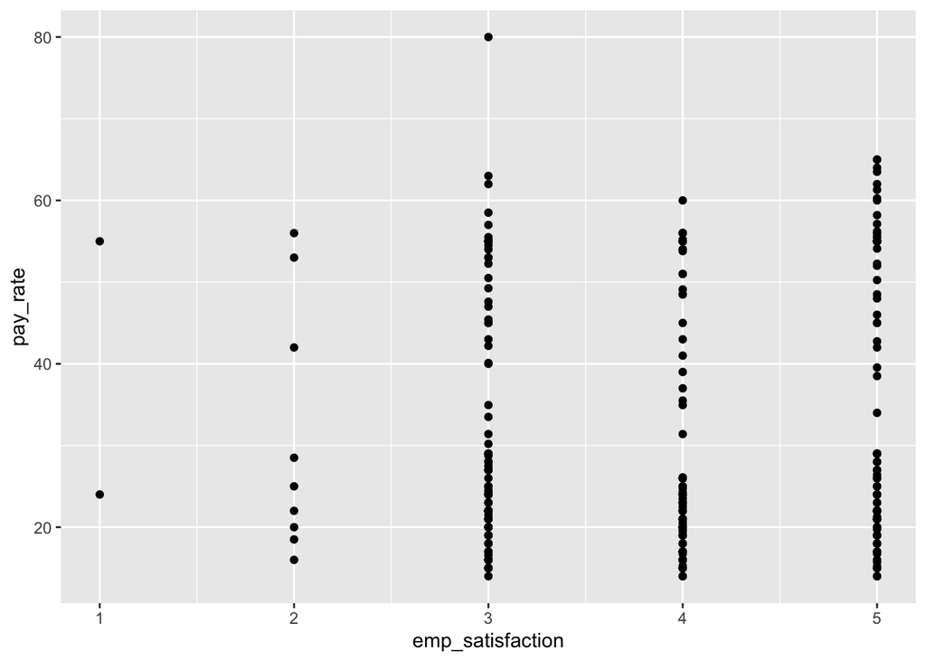

**Diversity**

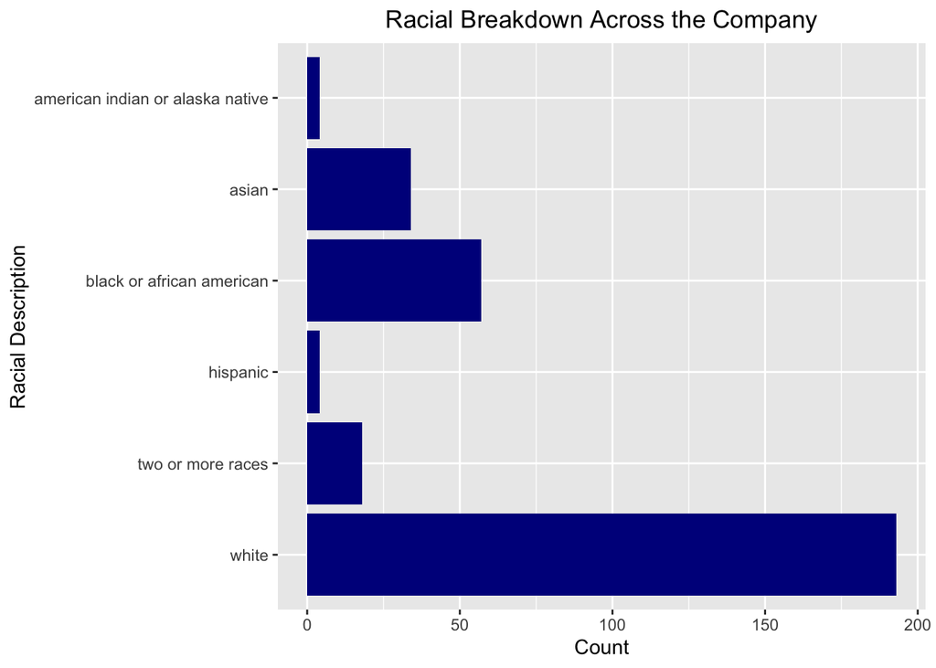

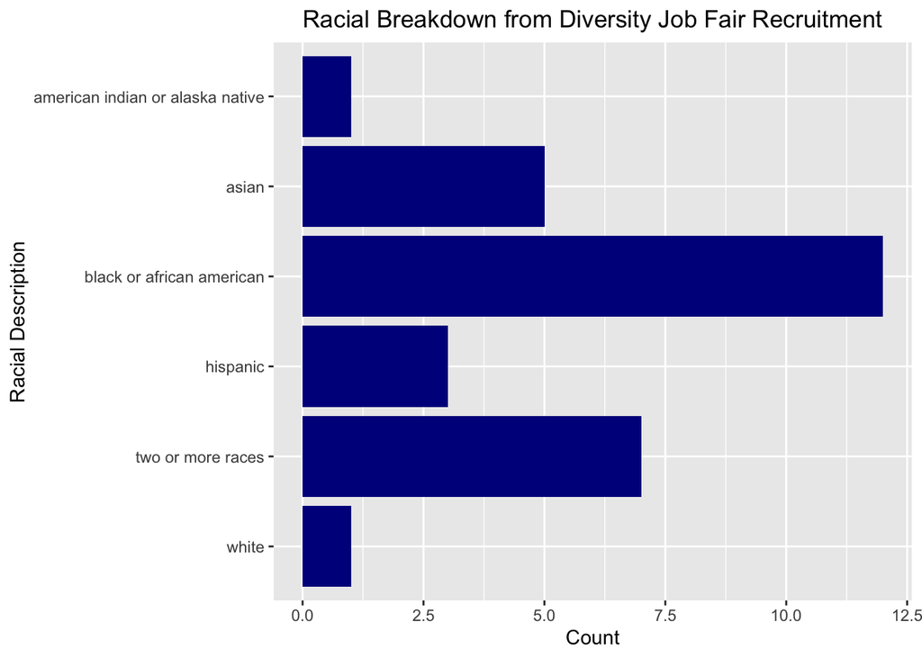

**Performance** This graph shows the overall picture of performance within the company. While it does include those who have left, it excludes those who are listed but have not yet started. They seem to have erroneously been assigned a performance category and removing them prevents inaccuracies in performance score reporting.

The vast majority of employees’ performance is rated as “fully meets” (78%). 12% of employees have a score of exceeds and 6% and 4% have scores of needs improvement and pip respectively.

Average Satisfaction Scores Grouped by Position

Where Position Has More Than One Employee

| Position | Average Score | Number of Employees |
| --- | --- | --- |
| it manager - db | 4.50 | 2 |
| sales manager | 4.33 | 3 |
| bi developer | 4.25 | 4 |
| software engineer | 4.22 | 9 |
| sr. network engineer | 4.20 | 5 |
| area sales manager | 4.00 | 27 |
| it support | 4.00 | 8 |
| senior bi developer | 4.00 | 3 |
| shared services manager | 4.00 | 2 |
| sr. dba | 4.00 | 2 |
| production technician i | 3.95 | 136 |
| database administrator | 3.80 | 5 |
| data analyst | 3.75 | 8 |
| production technician ii | 3.75 | 57 |
| accountant i | 3.67 | 3 |
| sr. accountant | 3.50 | 2 |
| production manager | 3.36 | 14 |
| administrative assistant | 3.33 | 3 |
| network engineer | 3.20 | 5 |

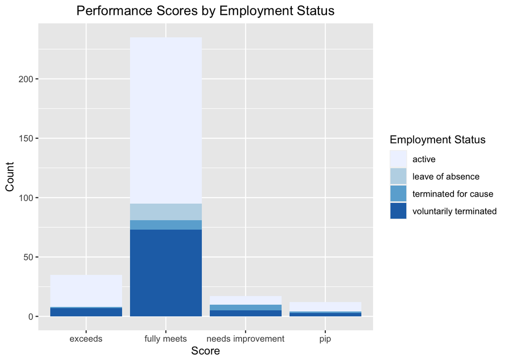

**Employee Satisfaction Levels**

Employee satisfaction is measured on a scale of 1-5, with 5 indicating the highest satisfaction. Across the dataset, the median scoring for employee satisfaction is 4. It is notable that while employees with the highest performance level of “exceeds” is the only category where the mode is 5, they do not seem to be significantly more satisfied than those with other performance levels. It is unsuprising that employees with the “needs improvement” and “pip” performance levels have disproportionately incidence of a satisfaction level of 2 and two people have reported a satisfaction level of 1.

```
## [1] 4
```

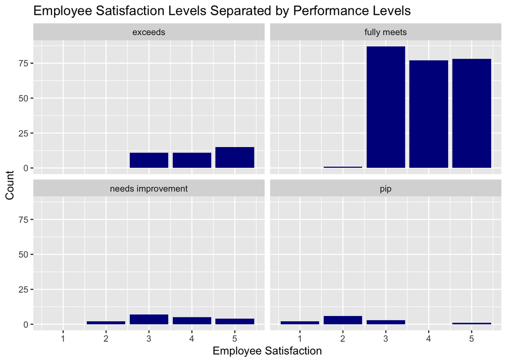

**Gender Pay Gap**

On average, men earn $33.70 compared to $29.47 for women. On average, men earn more than women in nine different positions. The position with the highest discrepancy is IT support workers where men earn a mean of $38.66 compared to $32.18 for women. On average, women earn more than men in six different positions with the largest discrepancy being for software engineers where women earn an average of 52.33 compared to the 48.56 earned by men.

**Staff Turnover**

There are a total of 310 staff records, with 196 currently employed and 11 due to onboard. The rest have all left, the breakdown for their reasons of leaving are as follows:

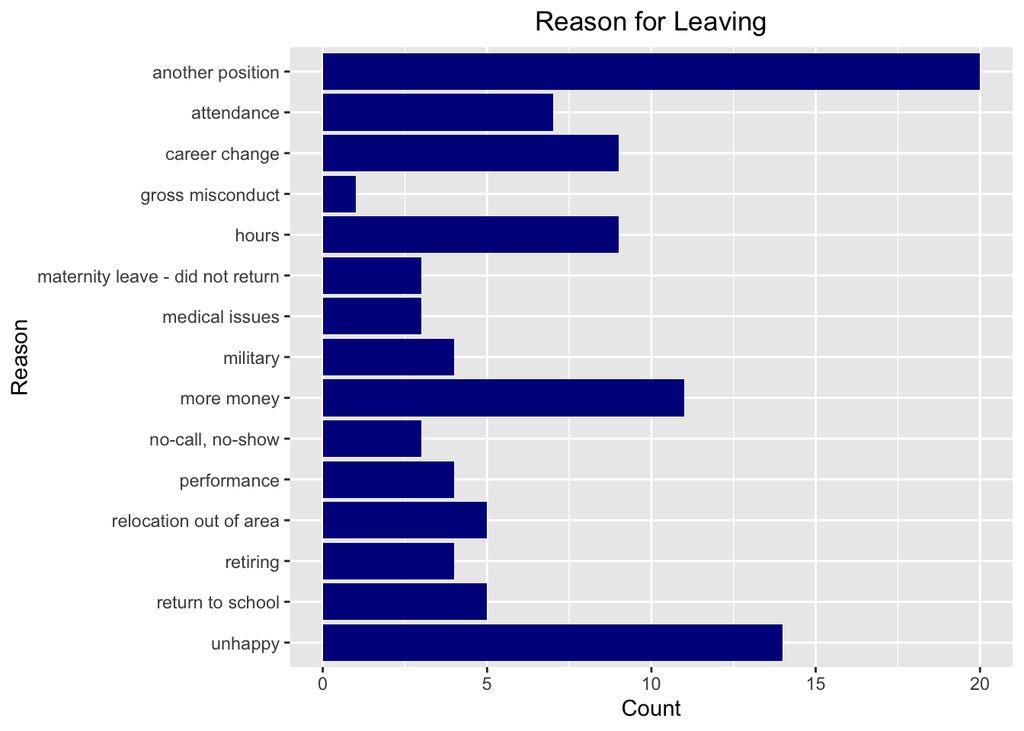

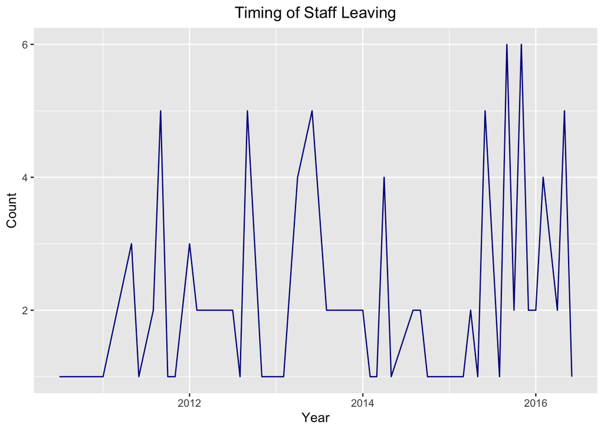